# S.Figure 4

# Associations between variance-based polygenic scores (vPGS) and phenotypic variabilty measured in unrelated indiviuals using squared z-scores, and in twin pairs via sibling-differences.

**Note:** None of the associations were significant after Bonferroni correction (P<0.003)

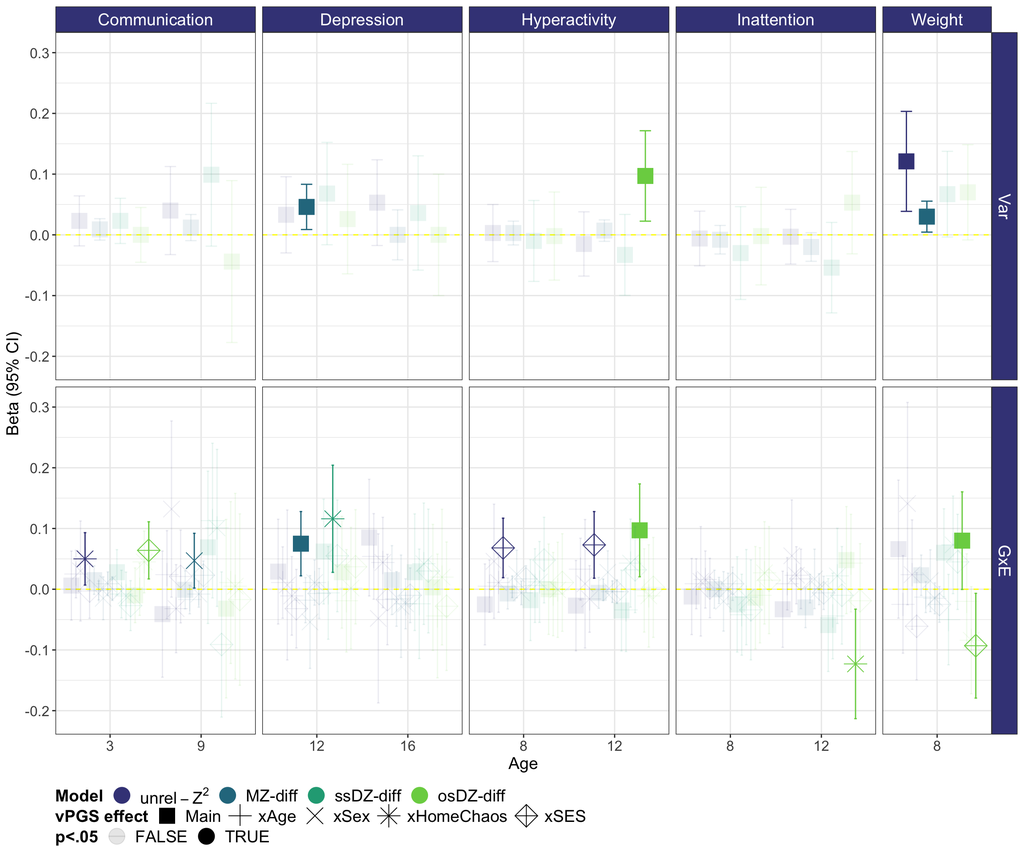

**Models**: **Z<sup>2</sup>**, squared z-scores regressed on vPGS using a linear model in a sample of unrelated individuals; **MZ-diff**, twin level phenotypic variability computed as the standard deviation (SD) for the twins phenotypic values, regressed on vPGS (identical for MZ twins; twin pair is the unit of analysis); **DZ-diff**, twin level phenotypic-SD values regressed on vPGS-SD values and the mean-vPGS value (vPGS vary in DZ twins; twin pair is the unit of analysis; estimated in same-sex pairs [ss] and opposite-sex pairs separately). vPGS were computed in TEDS participants, using GWA weights estimated from analyses of MoBa participants. LDpred2-auto was used to re-weight marginal SNP effects estimated from GWA, by integrating information from the SNP LD matrix, as well as the heritability and polygenicity of each trait. **Communication**: CCC, Children’s Communication Checklist (Ages 2 - 4); CDI, MacArthur Communicative Development Inventory (Age 9); **Depression**: SMFQ, Short Mood and Feelings Questionnaire; **Hyperactivity & Inattention:** CPRSRS, Conners Parent Rating Scale; **Weight:** residualised for the linear and quadratic effects of height

## Table of associations:

| Outcome | Age | vPGS | Model | Effect | BETA | SE | Z | P | N |
| --- | --- | --- | --- | --- | --- | --- | --- | --- | --- |
| Weight | 8 | vPGS | z2 | Main | 0.121 | 0.042 | 2.86 | 0.0043 | 2707 |
| Weight | 8 | MvPGS | mz | Main | 0.03 | 0.013 | 2.34 | 0.019 | 750 |
| Weight | 8 | SDvPGS | ss | Main | 0.067 | 0.036 | 1.85 | 0.065 | 975 |
| Weight | 8 | SDvPGS | os | Main | 0.07 | 0.04 | 1.76 | 0.079 | 921 |
| Weight | 8 | vPGS | z2 | Main | 0.066 | 0.058 | 1.14 | 0.26 | 2707 |
| Weight | 8 | vPGS | z2 | Sex | 0.141 | 0.085 | 1.66 | 0.097 | 2707 |
| Weight | 8 | vPGS | z2 | Age | -0.025 | 0.041 | 0.62 | 0.53 | 2707 |
| Weight | 8 | vPGS | z2 | Ses | -0.061 | 0.045 | 1.34 | 0.18 | 2707 |
| Weight | 8 | vPGS | z2 | Chaos | 0.024 | 0.046 | 0.53 | 0.6 | 2707 |
| Weight | 8 | MvPGS | mz | Main | 0.023 | 0.017 | 1.33 | 0.18 | 750 |

[output cut: 188 more lines]

## Full models

### Communication_03_vPGS

[output not shown]

|  | unrel-z^2 |  |  | MZ-SD |  |  | ssDZ-SD |  |  | osDZ-SD |  |  |
| --- | --- | --- | --- | --- | --- | --- | --- | --- | --- | --- | --- | --- |
| Predictors | Estimates | CI | p | Estimates | CI | p | Estimates | CI | p | Estimates | CI | p |
| (Intercept) | 1.00 | 0.96 – 1.04 | **0.00e+00** | 0.26 | 0.24 – 0.27 | **5.25e-141** | 0.28 | 0.26 – 0.31 | **5.76e-81** | 0.33 | 0.30 – 0.37 | **6.06e-86** |
| vPGS | 0.02 | -0.02 – 0.06 | 2.76e-01 |  |  |  |  |  |  |  |  |  |
| MvPGS |  |  |  | 0.01 | -0.01 – 0.03 | 2.96e-01 | -0.02 | -0.03 – 0.00 | 1.05e-01 | 0.00 | -0.02 – 0.03 | 7.38e-01 |
| SDvPGS |  |  |  |  |  |  | 0.02 | -0.01 – 0.06 | 2.29e-01 | -0.00 | -0.05 – 0.04 | 9.93e-01 |
| Observations | 4618 |  |  | 1312 |  |  | 1732 |  |  | 1574 |  |  |
| R<sup>2</sup> / R<sup>2</sup> adjusted | 0.000 / 0.000 |  |  | 0.001 / 0.000 |  |  | 0.002 / 0.001 |  |  | 0.000 / -0.001 |  |  |

|

### Communication_03_vPGSxE

[output not shown]

|  | unrel-z^2 |  |  | MZ-SD |  |  | ssDZ-SD |  |  | osDZ-SD |  |  |
| --- | --- | --- | --- | --- | --- | --- | --- | --- | --- | --- | --- | --- |
| Predictors | Estimates | CI | p | Estimates | CI | p | Estimates | CI | p | Estimates | CI | p |
| (Intercept) | 0.96 | 0.90 – 1.01 | **2.71e-209** | 0.25 | 0.23 – 0.28 | **1.15e-79** | 0.28 | 0.26 – 0.31 | **3.63e-81** | 0.34 | 0.31 – 0.37 | **1.47e-89** |
| vPGS | 0.01 | -0.05 – 0.06 | 8.32e-01 |  |  |  |  |  |  |  |  |  |
| Sex | 0.09 | 0.01 – 0.17 | **3.67e-02** | 0.00 | -0.03 – 0.04 | 9.32e-01 |  |  |  |  |  |  |
| MeanAge | 0.04 | 0.00 – 0.09 | **3.90e-02** | 0.02 | 0.00 – 0.03 | **3.98e-02** | 0.02 | -0.01 – 0.05 | 2.74e-01 | 0.01 | -0.02 – 0.04 | 6.75e-01 |
| Ses | -0.06 | -0.10 – -0.01 | **1.04e-02** | -0.01 | -0.03 – 0.01 | 1.78e-01 | 0.01 | -0.02 – 0.04 | 3.61e-01 | -0.05 | -0.08 – -0.01 | **5.84e-03** |
| Chaos | 0.10 | 0.06 – 0.14 | **9.73e-06** | 0.01 | -0.01 – 0.03 | 4.32e-01 | 0.04 | 0.01 – 0.07 | **9.90e-03** | 0.01 | -0.03 – 0.04 | 5.98e-01 |
| vPGS × Sex | 0.03 | -0.05 – 0.11 | 4.77e-01 |  |  |  |  |  |  |  |  |  |
| vPGS × MeanAge | 0.03 | -0.01 – 0.07 | 2.09e-01 |  |  |  |  |  |  |  |  |  |
| vPGS × Ses | -0.00 | -0.05 – 0.04 | 9.03e-01 |  |  |  |  |  |  |  |  |  |
| vPGS × Chaos | 0.05 | 0.01 – 0.09 | **2.47e-02** |  |  |  |  |  |  |  |  |  |
| MvPGS |  |  |  | 0.02 | -0.01 – 0.04 | 2.22e-01 | -0.02 | -0.03 – 0.00 | 1.16e-01 | 0.00 | -0.02 – 0.02 | 9.67e-01 |
| MvPGS × Sex |  |  |  | -0.01 | -0.05 – 0.02 | 4.13e-01 |  |  |  |  |  |  |
| MvPGS × MeanAge |  |  |  | -0.00 | -0.02 – 0.01 | 8.28e-01 |  |  |  |  |  |  |
| MvPGS × Ses |  |  |  | 0.00 | -0.02 – 0.02 | 9.38e-01 |  |  |  |  |  |  |
| MvPGS × Chaos |  |  |  | 0.01 | -0.01 – 0.03 | 3.46e-01 |  |  |  |  |  |  |
| SDvPGS |  |  |  |  |  |  | 0.03 | -0.01 – 0.07 | 1.49e-01 | -0.01 | -0.06 – 0.04 | 6.60e-01 |
| SDvPGS × MeanAge |  |  |  |  |  |  | -0.01 | -0.05 – 0.03 | 6.92e-01 | 0.00 | -0.04 – 0.04 | 9.95e-01 |
| SDvPGS × Ses |  |  |  |  |  |  | -0.03 | -0.07 – 0.01 | 2.01e-01 | 0.06 | 0.02 – 0.11 | **8.88e-03** |
| SDvPGS × Chaos |  |  |  |  |  |  | -0.01 | -0.05 – 0.03 | 5.92e-01 | 0.04 | -0.01 – 0.10 | 8.55e-02 |
| MeanAge × MvPGS |  |  |  |  |  |  | 0.02 | -0.00 – 0.04 | 8.99e-02 | 0.00 | -0.02 – 0.02 | 8.54e-01 |
| Ses × MvPGS |  |  |  |  |  |  | 0.00 | -0.02 – 0.02 | 7.92e-01 | 0.02 | -0.01 – 0.04 | 2.10e-01 |
| Chaos × MvPGS |  |  |  |  |  |  | 0.00 | -0.02 – 0.02 | 6.80e-01 | -0.01 | -0.03 – 0.02 | 5.09e-01 |
| Observations | 4618 |  |  | 1312 |  |  | 1732 |  |  | 1574 |  |  |
| R<sup>2</sup> / R<sup>2</sup> adjusted | 0.013 / 0.011 |  |  | 0.008 / 0.001 |  |  | 0.016 / 0.010 |  |  | 0.018 / 0.011 |  |  |

|

### Communication_09_vPGS

[output not shown]

|  | unrel-z^2 |  |  | MZ-SD |  |  | ssDZ-SD |  |  | osDZ-SD |  |  |
| --- | --- | --- | --- | --- | --- | --- | --- | --- | --- | --- | --- | --- |
| Predictors | Estimates | CI | p | Estimates | CI | p | Estimates | CI | p | Estimates | CI | p |
| (Intercept) | 1.00 | 0.93 – 1.07 | **2.08e-130** | 0.10 | 0.08 – 0.12 | **4.91e-16** | 0.29 | 0.21 – 0.37 | **4.53e-12** | 0.48 | 0.38 – 0.57 | **1.00e-21** |
| vPGS | 0.04 | -0.03 – 0.11 | 2.75e-01 |  |  |  |  |  |  |  |  |  |
| MvPGS |  |  |  | 0.01 | -0.01 – 0.03 | 3.06e-01 | 0.00 | -0.05 – 0.06 | 8.69e-01 | 0.01 | -0.05 – 0.07 | 7.11e-01 |
| SDvPGS |  |  |  |  |  |  | 0.10 | -0.02 – 0.22 | 9.92e-02 | -0.04 | -0.18 – 0.09 | 5.16e-01 |
| Observations | 1680 |  |  | 491 |  |  | 623 |  |  | 559 |  |  |
| R<sup>2</sup> / R<sup>2</sup> adjusted | 0.001 / 0.000 |  |  | 0.002 / 0.000 |  |  | 0.004 / 0.001 |  |  | 0.001 / -0.003 |  |  |

|

### Communication_09_vPGSxE

[output not shown]

|  | unrel-z^2 |  |  | MZ-SD |  |  | ssDZ-SD |  |  | osDZ-SD |  |  |
| --- | --- | --- | --- | --- | --- | --- | --- | --- | --- | --- | --- | --- |
| Predictors | Estimates | CI | p | Estimates | CI | p | Estimates | CI | p | Estimates | CI | p |
| (Intercept) | 0.91 | 0.81 – 1.02 | **9.38e-58** | 0.11 | 0.07 – 0.14 | **3.68e-09** | 0.29 | 0.21 – 0.38 | **2.99e-11** | 0.47 | 0.37 – 0.57 | **8.15e-18** |
| vPGS | -0.04 | -0.14 – 0.06 | 4.31e-01 |  |  |  |  |  |  |  |  |  |
| Sex | 0.19 | 0.04 – 0.33 | **1.25e-02** | 0.02 | -0.03 – 0.06 | 5.23e-01 |  |  |  |  |  |  |
| Age | 0.02 | -0.05 – 0.09 | 5.73e-01 | -0.03 | -0.05 – -0.00 | **3.21e-02** | -0.02 | -0.10 – 0.06 | 6.54e-01 | 0.01 | -0.08 – 0.10 | 8.22e-01 |
| Ses | -0.02 | -0.09 – 0.06 | 7.03e-01 | 0.01 | -0.02 – 0.03 | 6.43e-01 | 0.03 | -0.05 – 0.11 | 4.73e-01 | 0.05 | -0.05 – 0.15 | 3.53e-01 |
| Chaos | 0.14 | 0.07 – 0.22 | **1.63e-04** | 0.01 | -0.01 – 0.03 | 4.34e-01 | -0.02 | -0.11 – 0.06 | 6.02e-01 | 0.05 | -0.06 – 0.15 | 3.65e-01 |
| vPGS × Sex | 0.13 | -0.01 – 0.28 | 7.64e-02 |  |  |  |  |  |  |  |  |  |
| vPGS × Age | 0.02 | -0.05 – 0.10 | 5.21e-01 |  |  |  |  |  |  |  |  |  |
| vPGS × Ses | 0.02 | -0.05 – 0.10 | 5.80e-01 |  |  |  |  |  |  |  |  |  |
| vPGS × Chaos | -0.03 | -0.11 – 0.04 | 3.94e-01 |  |  |  |  |  |  |  |  |  |
| MvPGS |  |  |  | -0.00 | -0.03 – 0.03 | 9.73e-01 | -0.00 | -0.06 – 0.06 | 9.46e-01 | 0.02 | -0.06 – 0.09 | 6.77e-01 |
| MvPGS × Sex |  |  |  | 0.05 | 0.00 – 0.09 | **4.46e-02** |  |  |  |  |  |  |
| MvPGS × Age |  |  |  | -0.02 | -0.04 – 0.01 | 1.57e-01 |  |  |  |  |  |  |
| MvPGS × Ses |  |  |  | 0.02 | -0.00 – 0.05 | 6.04e-02 |  |  |  |  |  |  |
| MvPGS × Chaos |  |  |  | -0.01 | -0.03 – 0.01 | 4.76e-01 |  |  |  |  |  |  |
| SDvPGS |  |  |  |  |  |  | 0.07 | -0.06 – 0.19 | 2.76e-01 | -0.03 | -0.18 – 0.12 | 6.74e-01 |
| SDvPGS × Age |  |  |  |  |  |  | 0.11 | -0.01 – 0.24 | 8.22e-02 | 0.01 | -0.12 – 0.14 | 8.76e-01 |
| SDvPGS × Ses |  |  |  |  |  |  | -0.09 | -0.21 – 0.03 | 1.39e-01 | -0.02 | -0.16 – 0.13 | 8.13e-01 |
| SDvPGS × Chaos |  |  |  |  |  |  | 0.10 | -0.03 – 0.23 | 1.26e-01 | 0.00 | -0.15 – 0.16 | 9.53e-01 |
| Age × MvPGS |  |  |  |  |  |  | 0.01 | -0.04 – 0.07 | 6.87e-01 | -0.02 | -0.08 – 0.04 | 4.80e-01 |
| Ses × MvPGS |  |  |  |  |  |  | 0.02 | -0.03 – 0.08 | 3.93e-01 | -0.01 | -0.08 – 0.05 | 7.12e-01 |
| Chaos × MvPGS |  |  |  |  |  |  | -0.01 | -0.07 – 0.05 | 6.95e-01 | -0.03 | -0.10 – 0.04 | 3.68e-01 |
| Observations | 1680 |  |  | 491 |  |  | 623 |  |  | 559 |  |  |
| R<sup>2</sup> / R<sup>2</sup> adjusted | 0.018 / 0.013 |  |  | 0.033 / 0.015 |  |  | 0.036 / 0.018 |  |  | 0.010 / -0.010 |  |  |

|

### Depression_12_vPGS

[output not shown]

|  | unrel-z^2 |  |  | MZ-SD |  |  | ssDZ-SD |  |  | osDZ-SD |  |  |
| --- | --- | --- | --- | --- | --- | --- | --- | --- | --- | --- | --- | --- |
| Predictors | Estimates | CI | p | Estimates | CI | p | Estimates | CI | p | Estimates | CI | p |
| (Intercept) | 1.00 | 0.94 – 1.06 | **9.82e-187** | 0.30 | 0.26 – 0.34 | **3.77e-50** | 0.40 | 0.34 – 0.46 | **2.64e-37** | 0.46 | 0.39 – 0.52 | **1.41e-39** |
| vPGS | 0.03 | -0.03 – 0.10 | 3.06e-01 |  |  |  |  |  |  |  |  |  |
| MvPGS |  |  |  | 0.05 | 0.01 – 0.08 | **1.89e-02** | -0.03 | -0.07 – 0.01 | 1.84e-01 | -0.00 | -0.05 – 0.04 | 9.38e-01 |
| SDvPGS |  |  |  |  |  |  | 0.07 | -0.02 – 0.15 | 1.11e-01 | 0.03 | -0.06 – 0.12 | 5.76e-01 |
| Observations | 3099 |  |  | 862 |  |  | 1162 |  |  | 1052 |  |  |
| R<sup>2</sup> / R<sup>2</sup> adjusted | 0.000 / 0.000 |  |  | 0.006 / 0.005 |  |  | 0.004 / 0.002 |  |  | 0.000 / -0.002 |  |  |

|

### Depression_12_vPGSxE

[output not shown]

|  | unrel-z^2 |  |  | MZ-SD |  |  | ssDZ-SD |  |  | osDZ-SD |  |  |
| --- | --- | --- | --- | --- | --- | --- | --- | --- | --- | --- | --- | --- |
| Predictors | Estimates | CI | p | Estimates | CI | p | Estimates | CI | p | Estimates | CI | p |
| (Intercept) | 1.06 | 0.98 – 1.15 | **6.36e-118** | 0.29 | 0.24 – 0.34 | **2.55e-27** | 0.40 | 0.34 – 0.46 | **4.99e-37** | 0.46 | 0.39 – 0.52 | **3.67e-38** |
| vPGS | 0.03 | -0.06 – 0.12 | 5.12e-01 |  |  |  |  |  |  |  |  |  |
| Sex | -0.08 | -0.20 – 0.04 | 2.08e-01 | 0.02 | -0.05 – 0.09 | 5.91e-01 |  |  |  |  |  |  |
| Age | -0.04 | -0.09 – 0.02 | 2.32e-01 | -0.03 | -0.07 – 0.00 | 5.98e-02 | -0.03 | -0.08 – 0.03 | 3.02e-01 | -0.02 | -0.08 – 0.04 | 5.19e-01 |
| Ses | -0.10 | -0.17 – -0.03 | **2.86e-03** | 0.02 | -0.02 – 0.06 | 2.23e-01 | 0.01 | -0.05 – 0.07 | 7.76e-01 | -0.01 | -0.09 – 0.06 | 6.85e-01 |
| Chaos | 0.24 | 0.17 – 0.30 | **8.14e-13** | 0.06 | 0.03 – 0.10 | **9.98e-04** | 0.01 | -0.06 – 0.07 | 8.19e-01 | 0.06 | -0.01 – 0.14 | 8.72e-02 |
| vPGS × Sex | 0.01 | -0.12 – 0.13 | 9.17e-01 |  |  |  |  |  |  |  |  |  |
| vPGS × Age | 0.01 | -0.05 – 0.07 | 7.03e-01 |  |  |  |  |  |  |  |  |  |
| vPGS × Ses | -0.03 | -0.10 – 0.03 | 3.39e-01 |  |  |  |  |  |  |  |  |  |
| vPGS × Chaos | -0.01 | -0.08 – 0.05 | 7.29e-01 |  |  |  |  |  |  |  |  |  |
| MvPGS |  |  |  | 0.07 | 0.02 – 0.13 | **5.77e-03** | -0.03 | -0.07 – 0.01 | 1.82e-01 | 0.00 | -0.04 – 0.05 | 9.43e-01 |
| MvPGS × Sex |  |  |  | -0.05 | -0.13 – 0.02 | 1.67e-01 |  |  |  |  |  |  |
| MvPGS × Age |  |  |  | -0.02 | -0.06 – 0.02 | 3.49e-01 |  |  |  |  |  |  |
| MvPGS × Ses |  |  |  | -0.01 | -0.05 – 0.03 | 7.26e-01 |  |  |  |  |  |  |
| MvPGS × Chaos |  |  |  | 0.01 | -0.03 – 0.05 | 5.76e-01 |  |  |  |  |  |  |
| SDvPGS |  |  |  |  |  |  | 0.06 | -0.02 – 0.15 | 1.59e-01 | 0.03 | -0.06 – 0.12 | 5.51e-01 |
| SDvPGS × Age |  |  |  |  |  |  | -0.01 | -0.08 – 0.07 | 8.76e-01 | -0.02 | -0.10 – 0.07 | 6.56e-01 |
| SDvPGS × Ses |  |  |  |  |  |  | 0.06 | -0.04 – 0.15 | 2.38e-01 | 0.04 | -0.06 – 0.13 | 4.37e-01 |
| SDvPGS × Chaos |  |  |  |  |  |  | 0.12 | 0.03 – 0.20 | **1.07e-02** | 0.00 | -0.10 – 0.10 | 9.66e-01 |
| Age × MvPGS |  |  |  |  |  |  | -0.00 | -0.04 – 0.03 | 8.55e-01 | -0.02 | -0.07 – 0.02 | 3.08e-01 |
| Ses × MvPGS |  |  |  |  |  |  | -0.00 | -0.04 – 0.04 | 8.68e-01 | -0.03 | -0.08 – 0.02 | 2.82e-01 |
| Chaos × MvPGS |  |  |  |  |  |  | 0.01 | -0.03 – 0.05 | 7.85e-01 | 0.03 | -0.02 – 0.08 | 1.86e-01 |
| Observations | 3099 |  |  | 862 |  |  | 1162 |  |  | 1052 |  |  |
| R<sup>2</sup> / R<sup>2</sup> adjusted | 0.028 / 0.025 |  |  | 0.028 / 0.017 |  |  | 0.026 / 0.017 |  |  | 0.019 / 0.008 |  |  |

|

### Depression_16_vPGS

[output not shown]

|  | unrel-z^2 |  |  | MZ-SD |  |  | ssDZ-SD |  |  | osDZ-SD |  |  |
| --- | --- | --- | --- | --- | --- | --- | --- | --- | --- | --- | --- | --- |
| Predictors | Estimates | CI | p | Estimates | CI | p | Estimates | CI | p | Estimates | CI | p |
| (Intercept) | 1.00 | 0.93 – 1.07 | **3.15e-153** | 0.28 | 0.24 – 0.32 | **3.36e-39** | 0.38 | 0.32 – 0.45 | **8.64e-28** | 0.48 | 0.41 – 0.56 | **3.46e-36** |
| vPGS | 0.05 | -0.02 – 0.12 | 1.41e-01 |  |  |  |  |  |  |  |  |  |
| MvPGS |  |  |  | -0.00 | -0.04 – 0.04 | 9.88e-01 | 0.02 | -0.03 – 0.06 | 5.03e-01 | -0.01 | -0.06 – 0.04 | 8.06e-01 |
| SDvPGS |  |  |  |  |  |  | 0.04 | -0.06 – 0.13 | 4.58e-01 | 0.00 | -0.10 – 0.10 | 9.94e-01 |
| Observations | 2713 |  |  | 727 |  |  | 1006 |  |  | 960 |  |  |
| R<sup>2</sup> / R<sup>2</sup> adjusted | 0.001 / 0.000 |  |  | 0.000 / -0.001 |  |  | 0.001 / -0.001 |  |  | 0.000 / -0.002 |  |  |

|

### Depression_16_vPGSxE

[output not shown]

|  | unrel-z^2 |  |  | MZ-SD |  |  | ssDZ-SD |  |  | osDZ-SD |  |  |
| --- | --- | --- | --- | --- | --- | --- | --- | --- | --- | --- | --- | --- |
| Predictors | Estimates | CI | p | Estimates | CI | p | Estimates | CI | p | Estimates | CI | p |
| (Intercept) | 1.22 | 1.12 – 1.31 | **1.52e-127** | 0.32 | 0.27 – 0.38 | **3.56e-30** | 0.40 | 0.33 – 0.47 | **3.98e-29** | 0.49 | 0.42 – 0.57 | **7.98e-36** |
| vPGS | 0.08 | -0.01 – 0.18 | 8.56e-02 |  |  |  |  |  |  |  |  |  |
| Sex | -0.42 | -0.56 – -0.28 | **3.13e-09** | -0.10 | -0.18 – -0.01 | **2.04e-02** |  |  |  |  |  |  |
| Age | 0.01 | -0.06 – 0.08 | 7.22e-01 | 0.00 | -0.04 – 0.04 | 9.16e-01 | -0.01 | -0.07 – 0.05 | 7.65e-01 | 0.00 | -0.07 – 0.07 | 9.78e-01 |
| Ses | -0.01 | -0.09 – 0.06 | 7.46e-01 | 0.01 | -0.04 – 0.05 | 7.84e-01 | -0.01 | -0.08 – 0.06 | 7.05e-01 | 0.00 | -0.08 – 0.08 | 1.00e+00 |
| Chaos | 0.23 | 0.16 – 0.30 | **7.52e-10** | 0.03 | -0.02 – 0.07 | 2.20e-01 | 0.06 | -0.01 – 0.13 | 9.22e-02 | 0.05 | -0.03 – 0.13 | 2.19e-01 |
| vPGS × Sex | -0.05 | -0.19 – 0.09 | 4.97e-01 |  |  |  |  |  |  |  |  |  |
| vPGS × Age | 0.05 | -0.02 – 0.12 | 1.29e-01 |  |  |  |  |  |  |  |  |  |
| vPGS × Ses | -0.02 | -0.09 – 0.06 | 6.47e-01 |  |  |  |  |  |  |  |  |  |
| vPGS × Chaos | 0.04 | -0.03 – 0.12 | 2.41e-01 |  |  |  |  |  |  |  |  |  |
| MvPGS |  |  |  | 0.01 | -0.04 – 0.07 | 6.08e-01 | 0.00 | -0.05 – 0.05 | 9.31e-01 | -0.01 | -0.06 – 0.04 | 7.47e-01 |
| MvPGS × Sex |  |  |  | -0.03 | -0.11 – 0.06 | 5.24e-01 |  |  |  |  |  |  |
| MvPGS × Age |  |  |  | -0.02 | -0.06 – 0.03 | 4.92e-01 |  |  |  |  |  |  |
| MvPGS × Ses |  |  |  | -0.01 | -0.06 – 0.04 | 6.60e-01 |  |  |  |  |  |  |
| MvPGS × Chaos |  |  |  | -0.02 | -0.07 – 0.02 | 2.57e-01 |  |  |  |  |  |  |
| SDvPGS |  |  |  |  |  |  | 0.03 | -0.07 – 0.12 | 5.68e-01 | 0.00 | -0.10 – 0.11 | 9.54e-01 |
| SDvPGS × Age |  |  |  |  |  |  | -0.02 | -0.11 – 0.07 | 6.04e-01 | -0.04 | -0.14 – 0.06 | 3.99e-01 |
| SDvPGS × Ses |  |  |  |  |  |  | 0.03 | -0.07 – 0.13 | 5.67e-01 | -0.03 | -0.13 – 0.08 | 5.96e-01 |
| SDvPGS × Chaos |  |  |  |  |  |  | 0.04 | -0.06 – 0.14 | 4.15e-01 | 0.02 | -0.09 – 0.13 | 7.29e-01 |
| Age × MvPGS |  |  |  |  |  |  | 0.02 | -0.02 – 0.07 | 3.52e-01 | 0.02 | -0.02 – 0.07 | 3.34e-01 |
| Ses × MvPGS |  |  |  |  |  |  | 0.04 | -0.01 – 0.09 | 8.90e-02 | -0.00 | -0.06 – 0.05 | 9.50e-01 |
| Chaos × MvPGS |  |  |  |  |  |  | 0.02 | -0.03 – 0.07 | 4.69e-01 | -0.02 | -0.08 – 0.04 | 5.44e-01 |
| Observations | 2713 |  |  | 727 |  |  | 1006 |  |  | 960 |  |  |
| R<sup>2</sup> / R<sup>2</sup> adjusted | 0.030 / 0.027 |  |  | 0.012 / -0.000 |  |  | 0.023 / 0.012 |  |  | 0.014 / 0.002 |  |  |

|

### Hyperactivity_08_vPGS

[output not shown]

|  | unrel-z^2 |  |  | MZ-SD |  |  | ssDZ-SD |  |  | osDZ-SD |  |  |
| --- | --- | --- | --- | --- | --- | --- | --- | --- | --- | --- | --- | --- |
| Predictors | Estimates | CI | p | Estimates | CI | p | Estimates | CI | p | Estimates | CI | p |
| (Intercept) | 1.00 | 0.95 – 1.05 | **1.40e-299** | 0.19 | 0.17 – 0.21 | **6.83e-72** | 0.48 | 0.44 – 0.53 | **1.08e-81** | 0.54 | 0.49 – 0.59 | **1.13e-82** |
| vPGS | 0.00 | -0.04 – 0.05 | 9.10e-01 |  |  |  |  |  |  |  |  |  |
| MvPGS |  |  |  | 0.00 | -0.02 – 0.02 | 7.66e-01 | -0.01 | -0.04 – 0.02 | 6.25e-01 | -0.01 | -0.05 – 0.02 | 4.22e-01 |
| SDvPGS |  |  |  |  |  |  | -0.01 | -0.08 – 0.06 | 7.67e-01 | -0.00 | -0.07 – 0.07 | 9.62e-01 |
| Observations | 3213 |  |  | 880 |  |  | 1174 |  |  | 1121 |  |  |
| R<sup>2</sup> / R<sup>2</sup> adjusted | 0.000 / -0.000 |  |  | 0.000 / -0.001 |  |  | 0.000 / -0.001 |  |  | 0.001 / -0.001 |  |  |

|

### Hyperactivity_08_vPGSxE

[output not shown]

|  | unrel-z^2 |  |  | MZ-SD |  |  | ssDZ-SD |  |  | osDZ-SD |  |  |
| --- | --- | --- | --- | --- | --- | --- | --- | --- | --- | --- | --- | --- |
| Predictors | Estimates | CI | p | Estimates | CI | p | Estimates | CI | p | Estimates | CI | p |
| (Intercept) | 0.94 | 0.87 – 1.00 | **1.10e-151** | 0.17 | 0.14 – 0.19 | **1.09e-33** | 0.50 | 0.45 – 0.54 | **1.94e-83** | 0.54 | 0.49 – 0.59 | **9.40e-80** |
| vPGS | -0.03 | -0.09 – 0.04 | 4.52e-01 |  |  |  |  |  |  |  |  |  |
| Sex | 0.16 | 0.07 – 0.26 | **6.09e-04** | 0.05 | 0.01 – 0.09 | **1.04e-02** |  |  |  |  |  |  |
| Age | -0.01 | -0.05 – 0.04 | 8.13e-01 | -0.00 | -0.02 – 0.01 | 7.17e-01 | 0.01 | -0.03 – 0.05 | 6.24e-01 | -0.00 | -0.05 – 0.04 | 9.29e-01 |
| Ses | -0.01 | -0.06 – 0.04 | 8.17e-01 | 0.02 | -0.00 – 0.04 | 5.45e-02 | -0.02 | -0.06 – 0.03 | 5.10e-01 | 0.03 | -0.02 – 0.09 | 2.37e-01 |
| Chaos | 0.20 | 0.15 – 0.25 | **1.98e-15** | 0.02 | -0.00 – 0.04 | 7.80e-02 | 0.05 | 0.00 – 0.10 | **3.78e-02** | 0.07 | 0.01 – 0.12 | **1.52e-02** |
| vPGS × Sex | 0.05 | -0.05 – 0.14 | 3.44e-01 |  |  |  |  |  |  |  |  |  |
| vPGS × Age | 0.00 | -0.04 – 0.05 | 8.35e-01 |  |  |  |  |  |  |  |  |  |
| vPGS × Ses | 0.07 | 0.02 – 0.12 | **7.28e-03** |  |  |  |  |  |  |  |  |  |
| vPGS × Chaos | 0.01 | -0.04 – 0.06 | 6.65e-01 |  |  |  |  |  |  |  |  |  |
| MvPGS |  |  |  | -0.01 | -0.03 – 0.02 | 6.25e-01 | -0.01 | -0.05 – 0.02 | 4.00e-01 | -0.01 | -0.05 – 0.02 | 4.60e-01 |
| MvPGS × Sex |  |  |  | 0.02 | -0.01 – 0.06 | 2.04e-01 |  |  |  |  |  |  |
| MvPGS × Age |  |  |  | 0.00 | -0.01 – 0.02 | 6.85e-01 |  |  |  |  |  |  |
| MvPGS × Ses |  |  |  | 0.02 | -0.00 – 0.04 | 9.87e-02 |  |  |  |  |  |  |
| MvPGS × Chaos |  |  |  | -0.01 | -0.03 – 0.01 | 5.56e-01 |  |  |  |  |  |  |
| SDvPGS |  |  |  |  |  |  | -0.02 | -0.08 – 0.05 | 5.87e-01 | 0.00 | -0.07 – 0.07 | 9.96e-01 |
| SDvPGS × Age |  |  |  |  |  |  | 0.01 | -0.05 – 0.07 | 8.42e-01 | -0.01 | -0.08 – 0.06 | 8.06e-01 |
| SDvPGS × Ses |  |  |  |  |  |  | 0.05 | -0.02 – 0.12 | 1.83e-01 | 0.01 | -0.07 – 0.09 | 7.95e-01 |
| SDvPGS × Chaos |  |  |  |  |  |  | 0.01 | -0.06 – 0.08 | 7.17e-01 | -0.00 | -0.08 – 0.08 | 9.87e-01 |
| Age × MvPGS |  |  |  |  |  |  | 0.02 | -0.01 – 0.05 | 3.03e-01 | -0.00 | -0.03 – 0.03 | 8.61e-01 |
| Ses × MvPGS |  |  |  |  |  |  | 0.03 | -0.00 – 0.07 | 6.35e-02 | 0.02 | -0.02 – 0.06 | 2.66e-01 |
| Chaos × MvPGS |  |  |  |  |  |  | 0.01 | -0.02 – 0.05 | 5.52e-01 | 0.05 | 0.01 – 0.08 | **1.48e-02** |
| Observations | 3213 |  |  | 880 |  |  | 1174 |  |  | 1121 |  |  |
| R<sup>2</sup> / R<sup>2</sup> adjusted | 0.031 / 0.028 |  |  | 0.021 / 0.011 |  |  | 0.020 / 0.011 |  |  | 0.021 / 0.011 |  |  |

|

### Hyperactivity_12_vPGS

[output not shown]

|  | unrel-z^2 |  |  | MZ-SD |  |  | ssDZ-SD |  |  | osDZ-SD |  |  |
| --- | --- | --- | --- | --- | --- | --- | --- | --- | --- | --- | --- | --- |
| Predictors | Estimates | CI | p | Estimates | CI | p | Estimates | CI | p | Estimates | CI | p |
| (Intercept) | 1.00 | 0.95 – 1.05 | **9.54e-241** | 0.18 | 0.16 – 0.19 | **4.63e-69** | 0.49 | 0.45 – 0.54 | **8.60e-84** | 0.45 | 0.40 – 0.50 | **1.26e-57** |
| vPGS | -0.01 | -0.07 – 0.04 | 5.86e-01 |  |  |  |  |  |  |  |  |  |
| MvPGS |  |  |  | 0.01 | -0.01 – 0.03 | 4.20e-01 | 0.01 | -0.03 – 0.04 | 7.52e-01 | 0.02 | -0.01 – 0.05 | 2.40e-01 |
| SDvPGS |  |  |  |  |  |  | -0.03 | -0.10 – 0.03 | 3.37e-01 | 0.10 | 0.02 – 0.17 | **9.53e-03** |
| Observations | 3058 |  |  | 838 |  |  | 1152 |  |  | 1049 |  |  |
| R<sup>2</sup> / R<sup>2</sup> adjusted | 0.000 / -0.000 |  |  | 0.001 / -0.000 |  |  | 0.001 / -0.001 |  |  | 0.008 / 0.006 |  |  |

|

### Hyperactivity_12_vPGSxE

[output not shown]

|  | unrel-z^2 |  |  | MZ-SD |  |  | ssDZ-SD |  |  | osDZ-SD |  |  |
| --- | --- | --- | --- | --- | --- | --- | --- | --- | --- | --- | --- | --- |
| Predictors | Estimates | CI | p | Estimates | CI | p | Estimates | CI | p | Estimates | CI | p |
| (Intercept) | 0.89 | 0.82 – 0.97 | **4.12e-115** | 0.16 | 0.14 – 0.19 | **3.78e-35** | 0.49 | 0.44 – 0.54 | **1.15e-81** | 0.45 | 0.40 – 0.50 | **4.53e-55** |
| vPGS | -0.03 | -0.10 – 0.05 | 4.81e-01 |  |  |  |  |  |  |  |  |  |
| Sex | 0.27 | 0.17 – 0.38 | **5.28e-07** | 0.03 | -0.00 – 0.07 | 8.41e-02 |  |  |  |  |  |  |
| Age | 0.01 | -0.04 – 0.06 | 6.67e-01 | 0.00 | -0.01 – 0.02 | 7.87e-01 | -0.01 | -0.05 – 0.04 | 7.55e-01 | -0.00 | -0.05 – 0.04 | 8.59e-01 |
| Ses | -0.03 | -0.09 – 0.02 | 2.43e-01 | 0.01 | -0.01 – 0.03 | 3.56e-01 | 0.03 | -0.01 – 0.08 | 1.57e-01 | 0.01 | -0.05 – 0.06 | 7.67e-01 |
| Chaos | 0.24 | 0.19 – 0.30 | **1.37e-17** | 0.00 | -0.02 – 0.02 | 7.41e-01 | 0.04 | -0.01 – 0.09 | 1.16e-01 | 0.05 | -0.01 – 0.10 | 1.01e-01 |
| vPGS × Sex | 0.01 | -0.10 – 0.11 | 8.70e-01 |  |  |  |  |  |  |  |  |  |
| vPGS × Age | 0.03 | -0.02 – 0.08 | 2.09e-01 |  |  |  |  |  |  |  |  |  |
| vPGS × Ses | 0.07 | 0.02 – 0.13 | **9.51e-03** |  |  |  |  |  |  |  |  |  |
| vPGS × Chaos | -0.02 | -0.07 – 0.04 | 5.76e-01 |  |  |  |  |  |  |  |  |  |
| MvPGS |  |  |  | -0.01 | -0.03 – 0.02 | 6.30e-01 | -0.00 | -0.03 – 0.03 | 9.99e-01 | 0.02 | -0.02 – 0.05 | 3.11e-01 |
| MvPGS × Sex |  |  |  | 0.03 | -0.01 – 0.06 | 1.24e-01 |  |  |  |  |  |  |
| MvPGS × Age |  |  |  | -0.00 | -0.02 – 0.02 | 9.06e-01 |  |  |  |  |  |  |
| MvPGS × Ses |  |  |  | -0.00 | -0.02 – 0.01 | 6.55e-01 |  |  |  |  |  |  |
| MvPGS × Chaos |  |  |  | -0.00 | -0.02 – 0.01 | 6.42e-01 |  |  |  |  |  |  |
| SDvPGS |  |  |  |  |  |  | -0.04 | -0.10 – 0.03 | 3.04e-01 | 0.10 | 0.02 – 0.17 | **1.28e-02** |
| SDvPGS × Age |  |  |  |  |  |  | -0.03 | -0.10 – 0.03 | 3.29e-01 | -0.00 | -0.07 – 0.07 | 9.48e-01 |
| SDvPGS × Ses |  |  |  |  |  |  | 0.03 | -0.04 – 0.10 | 3.73e-01 | 0.00 | -0.08 – 0.09 | 9.52e-01 |
| SDvPGS × Chaos |  |  |  |  |  |  | 0.04 | -0.03 – 0.12 | 2.37e-01 | -0.01 | -0.10 – 0.07 | 7.90e-01 |
| Age × MvPGS |  |  |  |  |  |  | 0.01 | -0.02 – 0.04 | 4.50e-01 | -0.02 | -0.05 – 0.02 | 3.05e-01 |
| Ses × MvPGS |  |  |  |  |  |  | 0.03 | -0.01 – 0.06 | 9.99e-02 | 0.02 | -0.02 – 0.05 | 4.16e-01 |
| Chaos × MvPGS |  |  |  |  |  |  | 0.02 | -0.02 – 0.05 | 3.75e-01 | 0.03 | -0.00 – 0.07 | 7.21e-02 |
| Observations | 3058 |  |  | 838 |  |  | 1152 |  |  | 1049 |  |  |
| R<sup>2</sup> / R<sup>2</sup> adjusted | 0.043 / 0.040 |  |  | 0.009 / -0.002 |  |  | 0.028 / 0.019 |  |  | 0.017 / 0.007 |  |  |

|

### Inattention_08_vPGS

[output not shown]

|  | unrel-z^2 |  |  | MZ-SD |  |  | ssDZ-SD |  |  | osDZ-SD |  |  |
| --- | --- | --- | --- | --- | --- | --- | --- | --- | --- | --- | --- | --- |
| Predictors | Estimates | CI | p | Estimates | CI | p | Estimates | CI | p | Estimates | CI | p |
| (Intercept) | 1.00 | 0.95 – 1.05 | **1.39e-319** | 0.27 | 0.24 – 0.29 | **2.59e-81** | 0.57 | 0.52 – 0.63 | **1.01e-82** | 0.63 | 0.57 – 0.68 | **3.36e-88** |
| vPGS | -0.01 | -0.05 – 0.04 | 7.95e-01 |  |  |  |  |  |  |  |  |  |
| MvPGS |  |  |  | -0.01 | -0.03 – 0.02 | 4.96e-01 | 0.01 | -0.03 – 0.04 | 7.04e-01 | -0.01 | -0.05 – 0.03 | 7.92e-01 |
| SDvPGS |  |  |  |  |  |  | -0.03 | -0.11 – 0.05 | 4.41e-01 | -0.00 | -0.08 – 0.08 | 9.69e-01 |
| Observations | 3207 |  |  | 882 |  |  | 1170 |  |  | 1118 |  |  |
| R<sup>2</sup> / R<sup>2</sup> adjusted | 0.000 / -0.000 |  |  | 0.001 / -0.001 |  |  | 0.001 / -0.001 |  |  | 0.000 / -0.002 |  |  |

|